```python
# This Python 3 environment comes with many helpful analytics libraries installed
# It is defined by the kaggle/python Docker image: https://github.com/kaggle/docker-python
# For example, here's several helpful packages to load

import numpy as np # linear algebra
import pandas as pd # data processing, CSV file I/O (e.g. pd.read_csv)

# Input data files are available in the read-only "../input/" directory
# For example, running this (by clicking run or pressing Shift+Enter) will list all files under the input directory

import os
for dirname, _, filenames in os.walk('/kaggle/input'):
    for filename in filenames:
        print(os.path.join(dirname, filename))

# You can write up to 5GB to the current directory (/kaggle/working/) that gets preserved as output when you create a version using "Save & Run All"
# You can also write temporary files to /kaggle/temp/, but they won't be saved outside of the current session
```

```
/kaggle/input/house-prices-advanced-regression-techniques/train.csv
/kaggle/input/house-prices-advanced-regression-techniques/test.csv
/kaggle/input/house-prices-advanced-regression-techniques/sample_submission.csv
/kaggle/input/house-prices-advanced-regression-techniques/data_description.txt
```

# Importing Library

```python
import matplotlib.pyplot as plt
import seaborn as sns
```

# Visualize the Data

```python
# Load Data
train = pd.read_csv('../input/house-prices-advanced-regression-techniques/train.csv')
test = pd.read_csv('../input/house-prices-advanced-regression-techniques/test.csv')
```

```python
#top five row of data
train.head()
```

|  | Id | MSSubClass | MSZoning | LotFrontage | LotArea | Street | Alley | LotShape | LandContour | Utilities | ... | PoolArea | PoolQC | Fence | MiscFeature | MiscVal | MoSold | YrSold | SaleType | SaleCondition | SalePrice |
| --- | --- | --- | --- | --- | --- | --- | --- | --- | --- | --- | --- | --- | --- | --- | --- | --- | --- | --- | --- | --- | --- |
| 0 | 1 | 60 | RL | 65.0 | 8450 | Pave | NaN | Reg | Lvl | AllPub | ... | 0 | NaN | NaN | NaN | 0 | 2 | 2008 | WD | Normal | 208500 |
| 1 | 2 | 20 | RL | 80.0 | 9600 | Pave | NaN | Reg | Lvl | AllPub | ... | 0 | NaN | NaN | NaN | 0 | 5 | 2007 | WD | Normal | 181500 |
| 2 | 3 | 60 | RL | 68.0 | 11250 | Pave | NaN | IR1 | Lvl | AllPub | ... | 0 | NaN | NaN | NaN | 0 | 9 | 2008 | WD | Normal | 223500 |
| 3 | 4 | 70 | RL | 60.0 | 9550 | Pave | NaN | IR1 | Lvl | AllPub | ... | 0 | NaN | NaN | NaN | 0 | 2 | 2006 | WD | Abnorml | 140000 |
| 4 | 5 | 60 | RL | 84.0 | 14260 | Pave | NaN | IR1 | Lvl | AllPub | ... | 0 | NaN | NaN | NaN | 0 | 12 | 2008 | WD | Normal | 250000 |

5 rows × 81 columns

```python
test.head()
```

|  | Id | MSSubClass | MSZoning | LotFrontage | LotArea | Street | Alley | LotShape | LandContour | Utilities | ... | ScreenPorch | PoolArea | PoolQC | Fence | MiscFeature | MiscVal | MoSold | YrSold | SaleType | SaleCondition |
| --- | --- | --- | --- | --- | --- | --- | --- | --- | --- | --- | --- | --- | --- | --- | --- | --- | --- | --- | --- | --- | --- |
| 0 | 1461 | 20 | RH | 80.0 | 11622 | Pave | NaN | Reg | Lvl | AllPub | ... | 120 | 0 | NaN | MnPrv | NaN | 0 | 6 | 2010 | WD | Normal |
| 1 | 1462 | 20 | RL | 81.0 | 14267 | Pave | NaN | IR1 | Lvl | AllPub | ... | 0 | 0 | NaN | NaN | Gar2 | 12500 | 6 | 2010 | WD | Normal |
| 2 | 1463 | 60 | RL | 74.0 | 13830 | Pave | NaN | IR1 | Lvl | AllPub | ... | 0 | 0 | NaN | MnPrv | NaN | 0 | 3 | 2010 | WD | Normal |
| 3 | 1464 | 60 | RL | 78.0 | 9978 | Pave | NaN | IR1 | Lvl | AllPub | ... | 0 | 0 | NaN | NaN | NaN | 0 | 6 | 2010 | WD | Normal |
| 4 | 1465 | 120 | RL | 43.0 | 5005 | Pave | NaN | IR1 | HLS | AllPub | ... | 144 | 0 | NaN | NaN | NaN | 0 | 1 | 2010 | WD | Normal |

5 rows × 80 columns

```python
#dimension of train data
train.shape
```

```
(1460, 81)
```

```python
#dimension of test data
test.shape
```

```
(1459, 80)
```

As you can see dimension of test and train data is different, you can not merge the data, data exploration should be done indivisually

```python
train.info()
```

```
<class 'pandas.core.frame.DataFrame'>
RangeIndex: 1460 entries, 0 to 1459
Data columns (total 81 columns):
 #   Column         Non-Null Count  Dtype
---  ------         --------------  -----
 0   Id             1460 non-null   int64
 1   MSSubClass     1460 non-null   int64
 2   MSZoning       1460 non-null   object
 3   LotFrontage    1201 non-null   float64
 4   LotArea        1460 non-null   int64
 5   Street         1460 non-null   object
 6   Alley          91 non-null     object
 7   LotShape       1460 non-null   object
 8   LandContour    1460 non-null   object
 9   Utilities      1460 non-null   object
```

[output cut: 73 more lines]

# Analyse the target variable (Univariate Analysis)

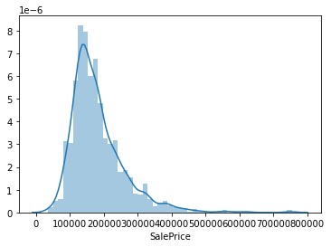

```python
sns.distplot(train['SalePrice']);
```

From the above you can see that Sales Price has Positive Skewness

```python
#skewness
print("Skewness: %f" % train['SalePrice'].skew())
```

```
Skewness: 1.882876
```

```python
#To remove the skewness we use the log function
SalePriceLog = np.log(train['SalePrice'])
SalePriceLog.skew()
```

```
0.12133506220520406
```

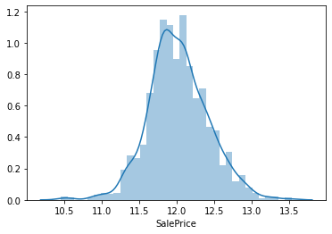

```python
#Plot after adjusted skewness
sns.distplot(SalePriceLog);
```

```python
SalePrice = SalePriceLog
```

# Bivariate Analysis

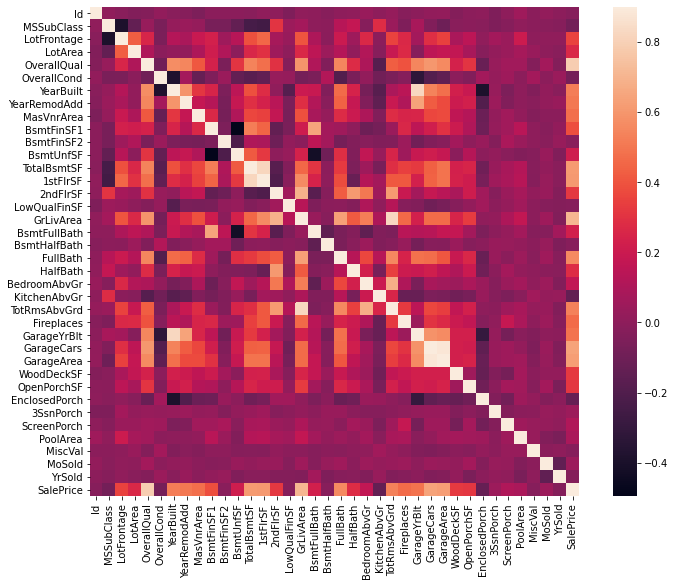

```python
#Correlation map to see how features are correlated with SalePrice
corrmat = train.corr()
plt.subplots(figsize=(12,9))
sns.heatmap(corrmat, vmax=0.9, square=True)
```

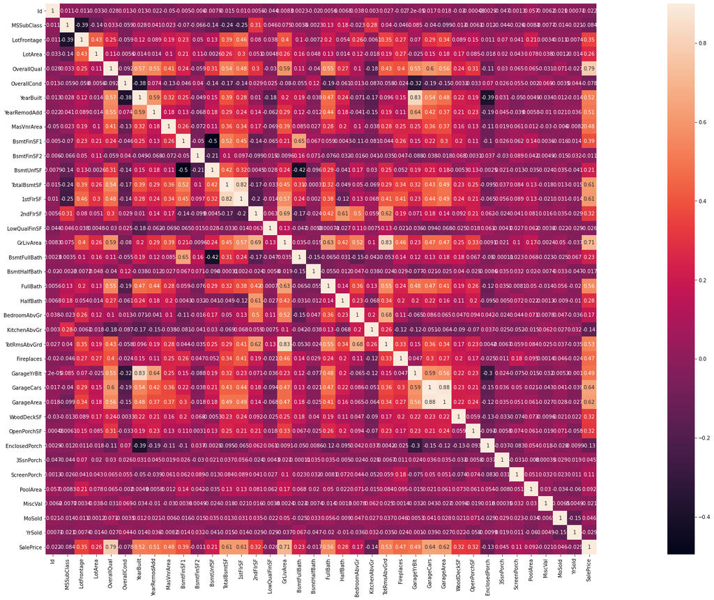

```python
#Correlation map to see how features are correlated with SalePrice
corrmat = train.corr()
plt.subplots(figsize=(50,20))
sns.heatmap(corrmat, vmax=0.9, square=True, annot=True)
```

```python
Num=corrmat['SalePrice'].sort_values(ascending=False).head(10).to_frame()

Num
```

|  | SalePrice |
| --- | --- |
| SalePrice | 1.000000 |
| OverallQual | 0.790982 |
| GrLivArea | 0.708624 |
| GarageCars | 0.640409 |
| GarageArea | 0.623431 |
| TotalBsmtSF | 0.613581 |
| 1stFlrSF | 0.605852 |
| FullBath | 0.560664 |
| TotRmsAbvGrd | 0.533723 |
| YearBuilt | 0.522897 |

# Missing Variable Treatment

```python
#missing data
total = train.isnull().sum().sort_values(ascending=False)
missing_data = pd.concat([total], axis=1, keys=['Total', 'Percent'])
missing_data.head(20)
```

|  | Total |
| --- | --- |
| PoolQC | 1453 |
| MiscFeature | 1406 |
| Alley | 1369 |
| Fence | 1179 |
| FireplaceQu | 690 |
| LotFrontage | 259 |
| GarageCond | 81 |
| GarageType | 81 |
| GarageYrBlt | 81 |
| GarageFinish | 81 |
| GarageQual | 81 |
| BsmtExposure | 38 |
| BsmtFinType2 | 38 |
| BsmtFinType1 | 37 |
| BsmtCond | 37 |
| BsmtQual | 37 |
| MasVnrArea | 8 |
| MasVnrType | 8 |
| Electrical | 1 |
| Utilities | 0 |

```python
#missing data
total = test.isnull().sum().sort_values(ascending=False)
missing_data = pd.concat([total], axis=1, keys=['Total', 'Percent'])
missing_data.head(20)
```

|  | Total |
| --- | --- |
| PoolQC | 1456 |
| MiscFeature | 1408 |
| Alley | 1352 |
| Fence | 1169 |
| FireplaceQu | 730 |
| LotFrontage | 227 |
| GarageCond | 78 |
| GarageQual | 78 |
| GarageYrBlt | 78 |
| GarageFinish | 78 |
| GarageType | 76 |
| BsmtCond | 45 |
| BsmtQual | 44 |
| BsmtExposure | 44 |
| BsmtFinType1 | 42 |
| BsmtFinType2 | 42 |
| MasVnrType | 16 |
| MasVnrArea | 15 |
| MSZoning | 4 |
| BsmtHalfBath | 2 |

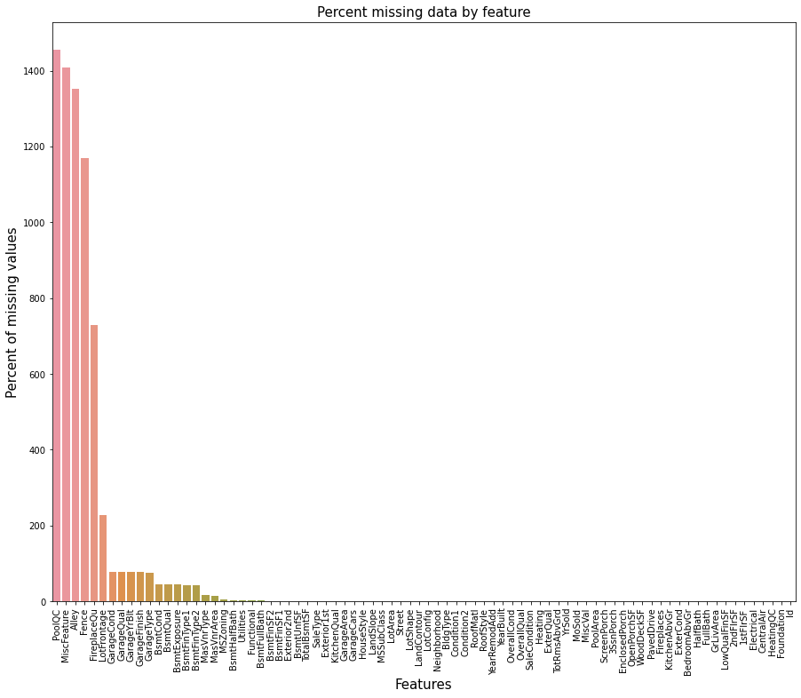

```python
#visulize missing value using sns plot
f, ax = plt.subplots(figsize=(15, 12))
plt.xticks(rotation='90')
sns.barplot(x=total.index, y=total)
plt.xlabel('Features', fontsize=15)
plt.ylabel('Percent of missing values', fontsize=15)
plt.title('Percent missing data by feature', fontsize=15)
```

More than 50% of data are missing for PoolQC, MiscFeature, Alley, Fence. So, we can drop the dataframe. Few data frame is uncorrelated, so we can drop them too.

```python
train.drop(['PoolQC', 'MiscFeature', 'Alley', 'Fence','FireplaceQu','GarageType','GarageFinish','GarageQual','GarageCond','MasVnrType'], axis=1 ,inplace=True)
test.drop(['PoolQC', 'MiscFeature', 'Alley', 'Fence','FireplaceQu','GarageType','GarageFinish','GarageQual','GarageCond','MasVnrType'], axis=1 ,inplace=True)
```

```python
# missing value treatment for continuous variable
for col in ('LotFrontage','GarageYrBlt','GarageCars','BsmtFinSF1','TotalBsmtSF','GarageArea','BsmtFinSF2','BsmtUnfSF','LotFrontage','GarageYrBlt','BsmtFullBath','BsmtHalfBath'):
    train[col]=train[col].fillna(train[col].mean())
    test[col]=test[col].fillna(test[col].mean())
```

```python
# missing value treatment for categorical variable
for col in ('BsmtQual','BsmtCond','BsmtExposure', 'BsmtFinType1', 'BsmtFinType2', 'MasVnrArea', 'Electrical','Exterior2nd','Exterior1st','KitchenQual','Functional','SaleType','Utilities','MSZoning','BsmtQual','BsmtCond','BsmtExposure', 'BsmtFinType1', 'BsmtFinType2', 'MasVnrArea', 'Electrical'):
    test[col]=test[col].fillna(test[col].mode()[0])
    train[col]=train[col].fillna(train[col].mode()[0])
```

```python
# checking if is there any missing variable left
train.isnull().sum().max()
```

```
0
```

```python
# checking if is there any missing variable left
test.isnull().sum().max()
```

```
0
```

# Outlier

```python
list_of_numerics=train.select_dtypes(include=['float','int']).columns
types= train.dtypes

outliers= train.apply(lambda x: sum(
                                 (x<(x.quantile(0.25)-1.5*(x.quantile(0.75)-x.quantile(0.25))))|
                                 (x>(x.quantile(0.75)+1.5*(x.quantile(0.75)-x.quantile(0.25))))
                                 if x.name in list_of_numerics else ''))


explo = pd.DataFrame({'Types': types,
                      'Outliers': outliers}).sort_values(by=['Types'],ascending=False)
explo.transpose()
```

|  | ExterQual | BsmtCond | Exterior1st | Exterior2nd | KitchenQual | ExterCond | Foundation | BsmtQual | BsmtExposure | Functional | ... | TotalBsmtSF | 1stFlrSF | 2ndFlrSF | LowQualFinSF | GrLivArea | BsmtFullBath | BsmtHalfBath | FullBath | HalfBath | SalePrice |
| --- | --- | --- | --- | --- | --- | --- | --- | --- | --- | --- | --- | --- | --- | --- | --- | --- | --- | --- | --- | --- | --- |
| Types | object | object | object | object | object | object | object | object | object | object | ... | int64 | int64 | int64 | int64 | int64 | int64 | int64 | int64 | int64 | int64 |
| Outliers | 0 | 0 | 0 | 0 | 0 | 0 | 0 | 0 | 0 | 0 | ... | 61 | 20 | 2 | 26 | 31 | 1 | 82 | 0 | 0 | 61 |

2 rows × 71 columns

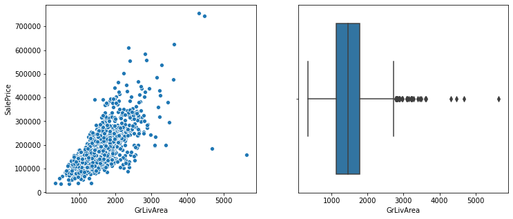

```python
fig, axes = plt.subplots(1,2, figsize=(12,5))

ax1= sns.scatterplot(x='GrLivArea', y='SalePrice', data= train,ax=axes[0])
ax2= sns.boxplot(x='GrLivArea', data= train,ax=axes[1])
```

```python
#removing outliers recomended by author
train= train[train['GrLivArea']<4000]
#test= test[test['GrLivArea']<4000]
```

# Variable Transformation

As you might know by now, we can’t have text in our data if we’re going to run any kind of model on it. So before we can run a model, we need to make this data ready for the model.

Numerical variable which are actually categorical

```python
train['MSSubClass'] = train['MSSubClass'].apply(str)
train['YrSold'] = train['YrSold'].astype(str)

test['MSSubClass'] = test['MSSubClass'].apply(str)
test['YrSold'] = test['YrSold'].astype(str)
```

Extracting the categorical column from train and test data.

```python
categorial_features_train = train.select_dtypes(include=[np.object])
categorial_features_train.head(2)
```

|  | MSSubClass | MSZoning | Street | LotShape | LandContour | Utilities | LotConfig | LandSlope | Neighborhood | Condition1 | ... | Heating | HeatingQC | CentralAir | Electrical | KitchenQual | Functional | PavedDrive | YrSold | SaleType | SaleCondition |
| --- | --- | --- | --- | --- | --- | --- | --- | --- | --- | --- | --- | --- | --- | --- | --- | --- | --- | --- | --- | --- | --- |
| 0 | 60 | RL | Pave | Reg | Lvl | AllPub | Inside | Gtl | CollgCr | Norm | ... | GasA | Ex | Y | SBrkr | Gd | Typ | Y | 2008 | WD | Normal |
| 1 | 20 | RL | Pave | Reg | Lvl | AllPub | FR2 | Gtl | Veenker | Feedr | ... | GasA | Ex | Y | SBrkr | TA | Typ | Y | 2007 | WD | Normal |

2 rows × 35 columns

```python
categorial_features_test = test.select_dtypes(include=[np.object])
categorial_features_test.head(2)
```

|  | MSSubClass | MSZoning | Street | LotShape | LandContour | Utilities | LotConfig | LandSlope | Neighborhood | Condition1 | ... | Heating | HeatingQC | CentralAir | Electrical | KitchenQual | Functional | PavedDrive | YrSold | SaleType | SaleCondition |
| --- | --- | --- | --- | --- | --- | --- | --- | --- | --- | --- | --- | --- | --- | --- | --- | --- | --- | --- | --- | --- | --- |
| 0 | 20 | RH | Pave | Reg | Lvl | AllPub | Inside | Gtl | NAmes | Feedr | ... | GasA | TA | Y | SBrkr | TA | Typ | Y | 2010 | WD | Normal |
| 1 | 20 | RL | Pave | IR1 | Lvl | AllPub | Corner | Gtl | NAmes | Norm | ... | GasA | TA | Y | SBrkr | Gd | Typ | Y | 2010 | WD | Normal |

2 rows × 35 columns

Label Encoding

```python
##Label Encoding
from sklearn.preprocessing import LabelEncoder
le = LabelEncoder()

label_encoders = {}
for column in categorial_features_train:
    label_encoders[column] = LabelEncoder()
    train[column] = label_encoders[column].fit_transform(train[column])
```

```python
##Label Encoding
from sklearn.preprocessing import LabelEncoder
le = LabelEncoder()

label_encoders = {}
for column in categorial_features_test:
    label_encoders[column] = LabelEncoder()
    test[column] = label_encoders[column].fit_transform(test[column])
```

```python
# dividing into dependent and independent variable data set
xtrain = train.drop('SalePrice', axis = 1)
ytrain = train['SalePrice']
```

# Modelling

```python
from sklearn.linear_model import LinearRegression
from sklearn.ensemble import RandomForestRegressor,  GradientBoostingRegressor
import xgboost as xgb
```

1. **Linear Regression**

```python
model1 = LinearRegression()
model1.fit(xtrain, ytrain)
```

```
LinearRegression(copy_X=True, fit_intercept=True, n_jobs=None, normalize=False)
```

```python
# score the model
model1.score(xtrain,ytrain)
```

```
0.899879503189483
```

1. **Gradient Boost**

Hyper Tunnning

```python
model2 = GradientBoostingRegressor(n_estimators=3000, learning_rate=0.05,
                                   max_depth=4, max_features='sqrt',
                                   min_samples_leaf=15, min_samples_split=10,
                                   loss='huber', random_state =5)
```

```python
model2.fit(xtrain,ytrain)
```

```
GradientBoostingRegressor(alpha=0.9, ccp_alpha=0.0, criterion='friedman_mse',
                          init=None, learning_rate=0.05, loss='huber',
                          max_depth=4, max_features='sqrt', max_leaf_nodes=None,
                          min_impurity_decrease=0.0, min_impurity_split=None,
                          min_samples_leaf=15, min_samples_split=10,
                          min_weight_fraction_leaf=0.0, n_estimators=3000,
                          n_iter_no_change=None, presort='deprecated',
                          random_state=5, subsample=1.0, tol=0.0001,
                          validation_fraction=0.1, verbose=0, warm_start=False)
```

```python
model2.score(xtrain,ytrain)
```

```
0.9906745236620275
```

1. **XGBoost**

Hyper Tunning

```python
model3 = xgb.XGBRegressor(colsample_bytree=0.4603, gamma=0.0468,
                             learning_rate=0.05, max_depth=3,
                             min_child_weight=1.7817, n_estimators=2200,
                             reg_alpha=0.4640, reg_lambda=0.8571,
                             subsample=0.5213, silent=1,
                             random_state =7, nthread = -1)
```

```python
model3.fit(xtrain, ytrain)
```

```
XGBRegressor(base_score=0.5, booster=None, colsample_bylevel=1,
             colsample_bynode=1, colsample_bytree=0.4603, gamma=0.0468,
             gpu_id=-1, importance_type='gain', interaction_constraints=None,
             learning_rate=0.05, max_delta_step=0, max_depth=3,
             min_child_weight=1.7817, missing=nan, monotone_constraints=None,
             n_estimators=2200, n_jobs=-1, nthread=-1, num_parallel_tree=1,
             objective='reg:squarederror', random_state=7, reg_alpha=0.464,
             reg_lambda=0.8571, scale_pos_weight=1, silent=1, subsample=0.5213,
             tree_method=None, validate_parameters=False, verbosity=None)
```

```python
model3.score(xtrain, ytrain)
```

```
0.9980329342046588
```

Prediction on test data of different model

```python
pred_1=model1.predict(test)
pred_2=model2.predict(test)
pred_3=model3.predict(test)
```

we take an average of predictions from all the models and use it to make the final prediction

```python
final_pred = (pred_1+pred_2+pred_3)/3
```

```python
final_pred
```

```
array([125161.00131379, 165750.4374407 , 190184.38904598, ...,
       166195.33125956, 118862.6986452 , 226756.43189829])
```

Creating Submission file

```python
sample_sub = pd.read_csv('../input/house-prices-advanced-regression-techniques/sample_submission.csv')
sample_sub.head()
```

|  | Id | SalePrice |
| --- | --- | --- |
| 0 | 1461 | 169277.052498 |
| 1 | 1462 | 187758.393989 |
| 2 | 1463 | 183583.683570 |
| 3 | 1464 | 179317.477511 |
| 4 | 1465 | 150730.079977 |

```python
sample_sub['SalePrice'] = final_pred
sample_sub.to_csv('final_submission1.csv', index=False)
```

# *If you like my kernel please upvote :)*